# Wildlife-Aircraft Collisions

3/15/2019

## Hi, we're Lauren, Michelle, & Tricia

> We will be talking about aircraft collisions with various types of wildlife (2000-) using data from the Federal Aviation Administration. Site: https://opendata.socrata.com/Government/FAA-National-Wildlife-Aircraft-Strike-Database-Yea/9r8b-gr46/data

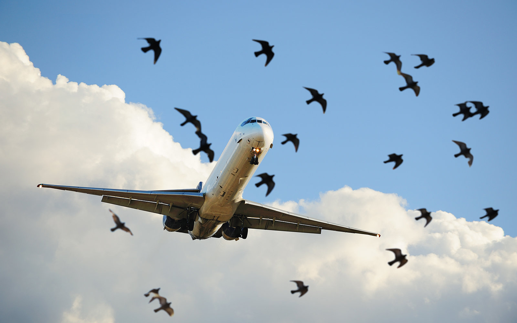

## Load the libraries

## Importing the Data without the NAs/Unknowns

## Lauren's Slides

## Summary functions!

```
## Observations: 59,971
## Variables: 20
## $ `Operator ID`         <chr> "UAL", NA, "UAL", NA, "UAL", NA, NA, NA, "…
## $ Operator              <chr> "UNITED AIRLINES", NA, "UNITED AIRLINES", …
## $ `Aircraft Type`       <chr> "B-737-500", NA, "A-320", NA, "B-777-200",…
## $ `Registration Number` <chr> "N933UA", NA, "N453UA", NA, "N777UA", NA, …
## $ Airport               <chr> NA, "PAJN", NA, "KOMA", NA, "KCLE", "KAUS"…
## $ Runway                <chr> NA, "8/26", NA, "18", NA, "24", "17R/35L",…
## $ State                 <chr> NA, "AK", NA, "NE", NA, "OH", "TX", "MD", …
## $ City                  <chr> NA, "JUNEAU INTL ARPT", NA, "EPPLEY AIRFIE…
## $ Date                  <chr> "09/03/2004", "09/09/2004", "10/27/2004", …
## $ `Height (feet)`       <dbl> NA, NA, NA, NA, NA, NA, NA, NA, 0, NA, NA,…
## $ Speed                 <dbl> NA, NA, NA, NA, NA, NA, NA, NA, NA, NA, NA…
## $ `Phase of Flight`     <chr> NA, NA, NA, NA, NA, NA, NA, NA, "Take-off …
## $ Sky                   <chr> NA, NA, NA, NA, NA, NA, NA, NA, "No Cloud"…
## $ Precipitation         <chr> NA, NA, NA, NA, NA, NA, NA, NA, "None", NA…
## $ Species               <chr> NA, "FOX SPARROW", NA, "KILLDEER", NA, "KI…
## $ `Birds Seen`          <chr> NA, NA, NA, NA, NA, NA, NA, NA, NA, NA, NA…
## $ `Birds Struck`        <chr> "1", "1", "1", "1", "1", "1", "1", "1", "1…
## $ Size                  <chr> NA, "Small", NA, "Small", NA, "Small", "Sm…
## $ `Cost of Repairs`     <dbl> NA, NA, NA, NA, NA, NA, NA, NA, NA, NA, NA…
## $ `Other Costs`         <dbl> NA, NA, NA, NA, NA, NA, NA, NA, NA, NA, NA…
```

```
##  [1] "Operator ID"         "Operator"            "Aircraft Type"
##  [4] "Registration Number" "Airport"             "Runway"
##  [7] "State"               "City"                "Date"
## [10] "Height (feet)"       "Speed"               "Phase of Flight"
## [13] "Sky"                 "Precipitation"       "Species"
## [16] "Birds Seen"          "Birds Struck"        "Size"
## [19] "Cost of Repairs"     "Other Costs"
```

```
## # A tibble: 1,199,420 x 2
##    key         value
##    <chr>       <chr>
##  1 Operator ID UAL
##  2 Operator ID <NA>
##  3 Operator ID UAL
##  4 Operator ID <NA>
##  5 Operator ID UAL
##  6 Operator ID <NA>
##  7 Operator ID <NA>
##  8 Operator ID <NA>
##  9 Operator ID QXE
## 10 Operator ID <NA>
## # … with 1,199,410 more rows
```

```
## # A tibble: 59,971 x 20
##    `Operator ID` Operator `Aircraft Type` `Registration N… Airport Runway
##    <chr>         <chr>    <chr>           <chr>            <chr>   <chr>
##  1 UAL           UNITED … B-737-500       N933UA           <NA>    <NA>
##  2 <NA>          <NA>     <NA>            <NA>             PAJN    8/26
##  3 UAL           UNITED … A-320           N453UA           <NA>    <NA>
##  4 <NA>          <NA>     <NA>            <NA>             KOMA    18
##  5 UAL           UNITED … B-777-200       N777UA           <NA>    <NA>
##  6 <NA>          <NA>     <NA>            <NA>             KCLE    24
##  7 <NA>          <NA>     <NA>            <NA>             KAUS    17R/3…
##  8 <NA>          <NA>     <NA>            <NA>             KBWI    10/28
##  9 QXE           HORIZON… CL-RJ700        <NA>             KOMA    14R
## 10 <NA>          <NA>     <NA>            <NA>             KMDW    31C
## # … with 59,961 more rows, and 14 more variables: State <chr>, City <chr>,
## #   Date <chr>, `Height (feet)` <dbl>, Speed <dbl>, `Phase of
## #   Flight` <chr>, Sky <chr>, Precipitation <chr>, Species <chr>, `Birds
## #   Seen` <chr>, `Birds Struck` <chr>, Size <chr>, `Cost of
## #   Repairs` <dbl>, `Other Costs` <dbl>
```

```
##  [1] "Operator ID"         "Operator"            "Aircraft Type"
##  [4] "Registration Number" "Airport"             "Runway"
##  [7] "State"               "City"                "Date"
## [10] "Height (feet)"       "Speed"               "Phase of Flight"
## [13] "Sky"                 "Precipitation"       "Species"
## [16] "Birds Seen"          "Birds Struck"        "Size"
## [19] "Cost of Repairs"     "Other Costs"
```

```
## # A tibble: 317 x 2
##    Operator           count
##    <chr>              <int>
##  1 <NA>               12476
##  2 UNITED AIRLINES     7833
##  3 BUSINESS            4931
##  4 SOUTHWEST AIRLINES  4192
##  5 FEDEX EXPRESS       3025
##  6 AMERICAN AIRLINES   2585
##  7 UPS AIRLINES        2252
##  8 DELTA AIR LINES     1905
##  9 NORTHWEST AIRLINES  1675
## 10 US AIRWAYS          1671
## # … with 307 more rows
```

```
## # A tibble: 484 x 2
##    Species               n
##    <chr>             <int>
##  1 <NA>              32924
##  2 MOURNING DOVE      2291
##  3 GULLS              2186
##  4 EUROPEAN STARLING  1427
##  5 AMERICAN KESTREL   1422
##  6 SPARROWS           1220
##  7 KILLDEER           1189
##  8 ROCK PIGEON        1045
##  9 HORNED LARK         832
## 10 BARN SWALLOW        753
## # … with 474 more rows
```

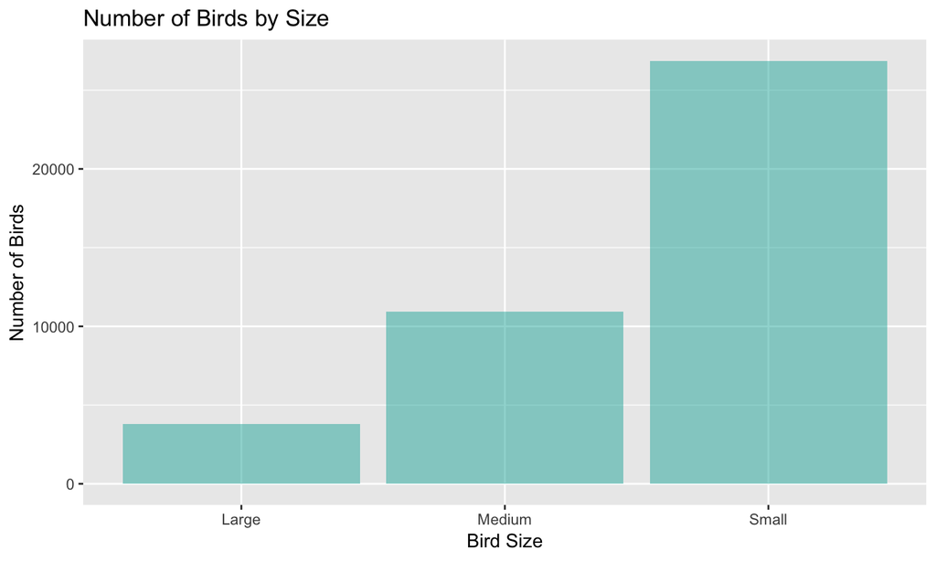

```
## # A tibble: 8,255 x 3
## # Groups:   Airport [1,342]
##    Airport Species count
##    <chr>   <chr>   <int>
##  1 <NA>    <NA>     7364
##  2 KDEN    <NA>     1286
##  3 KMEM    <NA>     1151
##  4 KORD    <NA>      852
##  5 KSMF    <NA>      680
##  6 KDFW    <NA>      655
##  7 KSDF    <NA>      642
##  8 KIAD    <NA>      552
##  9 KSFO    <NA>      416
## 10 KEWR    <NA>      340
## # … with 8,245 more rows
```

```
## # A tibble: 1,342 x 2
##    Airport count
##    <chr>   <int>
##  1 <NA>     8170
##  2 KDEN     2090
##  3 KDFW     1529
##  4 KMEM     1316
##  5 KORD     1305
##  6 KJFK     1199
##  7 KSMF      944
##  8 KPDX      829
##  9 KIAD      806
## 10 KMCI      804
## # … with 1,332 more rows
```

```
## # A tibble: 63 x 2
##    State count
##    <chr> <int>
##  1 <NA>   8611
##  2 CA     4857
##  3 TX     4041
##  4 FL     3174
##  5 NY     3025
##  6 IL     2451
##  7 CO     2430
##  8 OH     2109
##  9 TN     1914
## 10 MI     1654
## # … with 53 more rows
```

```
## # A tibble: 63 x 2
##    State     n
##    <chr> <int>
##  1 AB       28
##  2 AK      382
##  3 AL      362
##  4 AR      191
##  5 AZ     1216
##  6 BC       60
##  7 CA     4857
##  8 CO     2430
##  9 CT      524
## 10 DC     1218
## # … with 53 more rows
```

## Michelle's Slides

```
## # A tibble: 1,199,420 x 2
##    key         value
##    <chr>       <chr>
##  1 Operator ID UAL
##  2 Operator ID <NA>
##  3 Operator ID UAL
##  4 Operator ID <NA>
##  5 Operator ID UAL
##  6 Operator ID <NA>
##  7 Operator ID <NA>
##  8 Operator ID <NA>
##  9 Operator ID QXE
## 10 Operator ID <NA>
## # … with 1,199,410 more rows
```

## Is the data tidy? If so, how do you know?

No because values are not sorted into clean columns and have scattered observations that can be grouped together.

```
## # A tibble: 59,971 x 20
##    `Operator ID` Operator `Aircraft Type` `Registration N… Airport Runway
##    <chr>         <chr>    <chr>           <chr>            <chr>   <chr>
##  1 UAL           UNITED … B-737-500       N933UA           <NA>    <NA>
##  2 <NA>          <NA>     <NA>            <NA>             PAJN    8/26
##  3 UAL           UNITED … A-320           N453UA           <NA>    <NA>
##  4 <NA>          <NA>     <NA>            <NA>             KOMA    18
##  5 UAL           UNITED … B-777-200       N777UA           <NA>    <NA>
##  6 <NA>          <NA>     <NA>            <NA>             KCLE    24
##  7 <NA>          <NA>     <NA>            <NA>             KAUS    17R/3…
##  8 <NA>          <NA>     <NA>            <NA>             KBWI    10/28
##  9 QXE           HORIZON… CL-RJ700        <NA>             KOMA    14R
## 10 <NA>          <NA>     <NA>            <NA>             KMDW    31C
## # … with 59,961 more rows, and 14 more variables: State <chr>, City <chr>,
## #   Date <chr>, `Height (feet)` <dbl>, Speed <dbl>, `Phase of
## #   Flight` <chr>, Sky <chr>, Precipitation <chr>, Species <chr>, `Birds
## #   Seen` <chr>, `Birds Struck` <chr>, Size <chr>, `Cost of
## #   Repairs` <dbl>, `Other Costs` <dbl>
```

```
## # A tibble: 13,670 x 20
##    `Operator ID` Operator `Aircraft Type` `Registration N… Airport Runway
##    <chr>         <chr>    <chr>           <chr>            <chr>   <chr>
##  1 GOV           GOVERNM… RKWL AC-680     N50              KACY    31
##  2 GOV           GOVERNM… B-737           <NA>             KEFD    17R
##  3 FDX           FEDEX E… A-310           N411FE           KLCK    23L
##  4 MES           MESABA … SAAB-340        <NA>             KSBN    9R
##  5 TRS           AIRTRAN… CL-RJ100/200    <NA>             KDAY    24L
##  6 UAL           UNITED … B-777-200       N218UA           KIAD    19C
##  7 MES           MESABA … SAAB-340        N441XJ           KALO    18
##  8 AAL           AMERICA… B-737-800       N975AN           KMIA    26L
##  9 PVT           PRIVATE… HOMEBUILT       N3YM             KOAK    27R
## 10 NWA           NORTHWE… <NA>            <NA>             KDLH    9
## # … with 13,660 more rows, and 14 more variables: State <chr>, City <chr>,
## #   Date <chr>, `Height (feet)` <dbl>, Speed <dbl>, `Phase of
## #   Flight` <chr>, Sky <chr>, Precipitation <chr>, Species <chr>, `Birds
## #   Seen` <chr>, `Birds Struck` <chr>, Size <chr>, `Cost of
## #   Repairs` <dbl>, `Other Costs` <dbl>
```

```
## # A tibble: 12,636 x 3
##    Size   `Height (feet)` `Phase of Flight`
##    <chr>            <dbl> <chr>
##  1 Large              200 Approach
##  2 Medium             100 Approach
##  3 Small                0 Take-off run
##  4 Small                0 Take-off run
##  5 Small               25 Approach
##  6 Small                0 Landing Roll
##  7 Medium               0 Take-off run
##  8 Small                0 Landing Roll
##  9 Medium               0 Landing Roll
## 10 Medium               0 Landing Roll
## # … with 12,626 more rows
```

## Produce a summary of the birds that were struck. Be sure to include the minimum, maximum, and total n of species struck.

```
## # A tibble: 1 x 3
##   min_Species        max_Species total
##   <chr>              <chr>       <int>
## 1 ACADIAN FLYCATCHER ZEBRA DOVE  13670
```

## ## Between the Acadian Flycatcher and the Zebra Dove, produce a summary that shows the phase of flights they were struck at.

```
## # A tibble: 25 x 2
##    `Phase of Flight` Species
##    <chr>             <chr>
##  1 Take-off run      ZEBRA DOVE
##  2 Take-off run      ACADIAN FLYCATCHER
##  3 Take-off run      ZEBRA DOVE
##  4 Take-off run      ZEBRA DOVE
##  5 Landing Roll      ZEBRA DOVE
##  6 Landing Roll      ZEBRA DOVE
##  7 Landing Roll      ZEBRA DOVE
##  8 Landing Roll      ZEBRA DOVE
##  9 Landing Roll      ZEBRA DOVE
## 10 Landing Roll      ZEBRA DOVE
## # … with 15 more rows
```

## ## Graph the distribution of the height during flights that birds were struck at with a histogram and density curve.

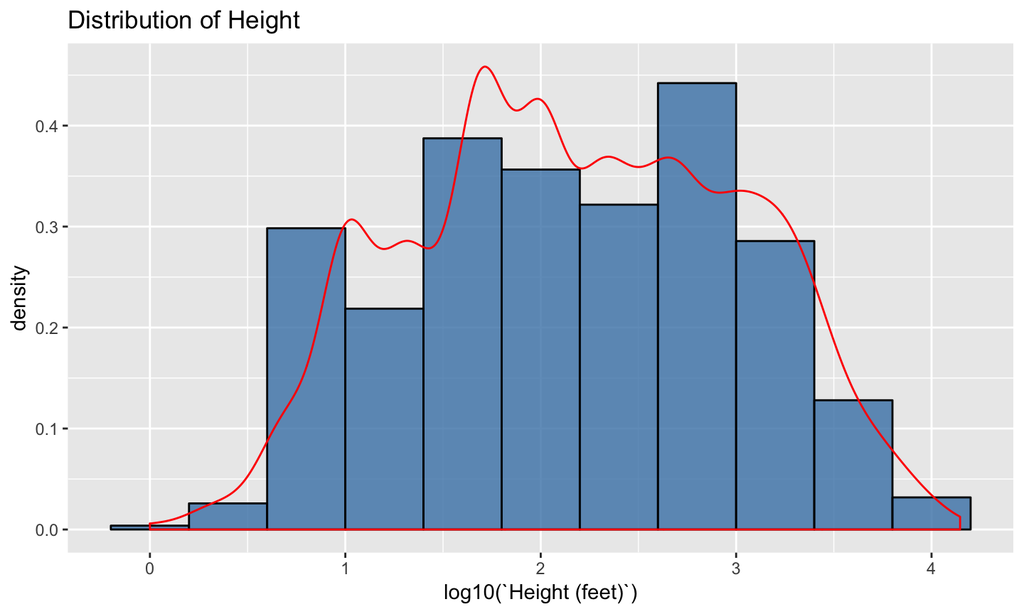

## Birds were struck at different phases and heights during airplane flights. What was the most common phase of flight that birds were struck? Likewise, what was the most common height that they were struck at?

## Plot

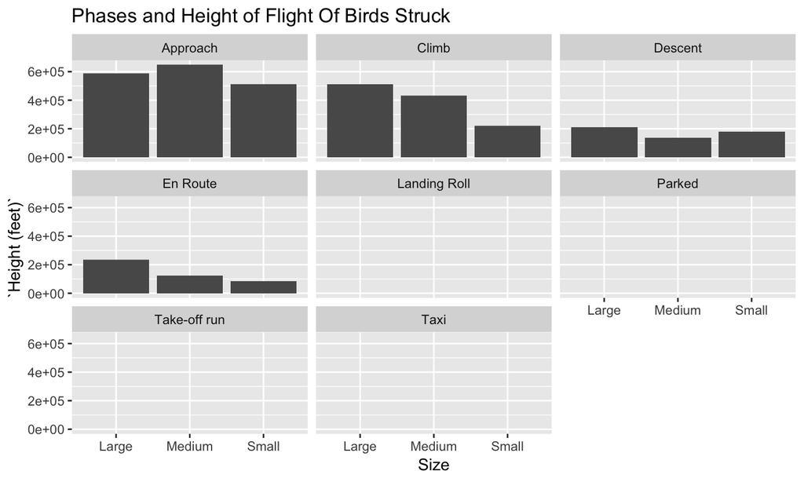

## What is the relationship between phase of flight and weather conditions at the time of flight?

## Plot

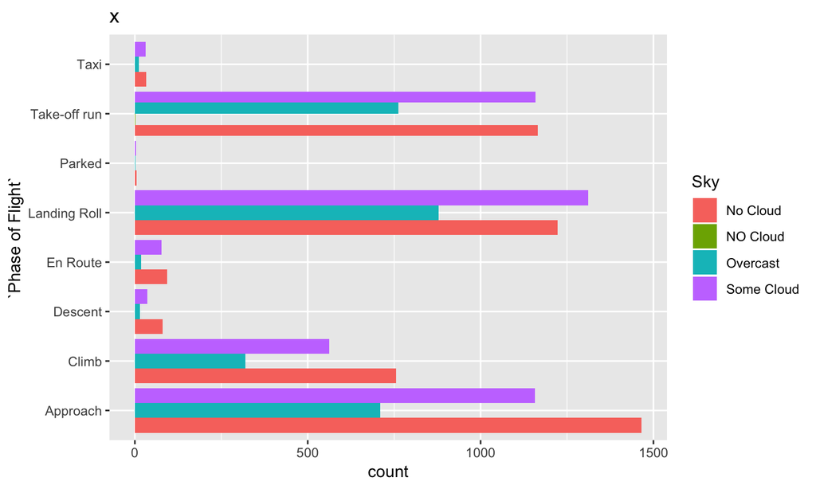

## Tricia's Slides

## Which species is recorded as being hit the most?

```
## # A tibble: 483 x 2
##    Species               n
##    <chr>             <int>
##  1 MOURNING DOVE      2291
##  2 GULLS              2186
##  3 EUROPEAN STARLING  1427
##  4 AMERICAN KESTREL   1422
##  5 SPARROWS           1220
##  6 KILLDEER           1189
##  7 ROCK PIGEON        1045
##  8 HORNED LARK         832
##  9 BARN SWALLOW        753
## 10 RED-TAILED HAWK     732
## # … with 473 more rows
```

## On average, how fast were the aircrafts going when they collided with the wildlife?

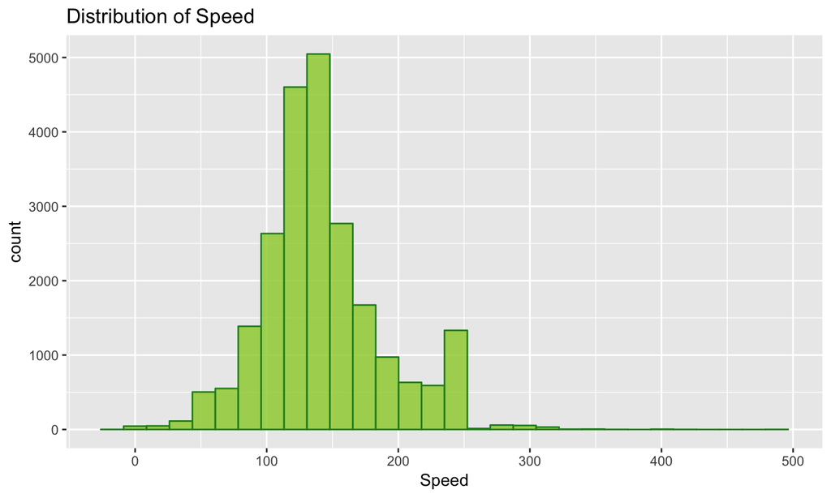

## American kestrels and red-tailed hawks are two common birds of prey. Let's compare the average speeds of the aircrafts when they collided with these birds.

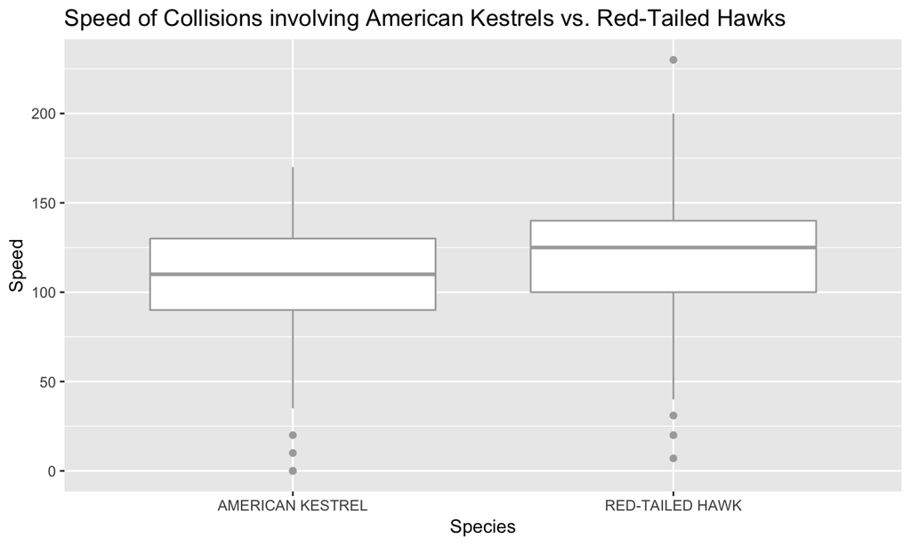

## Based on the boxplot, do you think these speeds are above average, average, or below average compared to other species?

These speeds lie near the peak of the distribution, suggesting that they are average.

## Let's see what the real average speed is and compare these speeds to the average.

```
## # A tibble: 1 x 1
##   avgspeed
##      <dbl>
## 1     143.
```

```
## # A tibble: 1 x 1
##   avgspeed_kestrel
##              <dbl>
## 1             107.
```

```
## # A tibble: 1 x 1
##   avgspeed_hawk
##           <dbl>
## 1          121.
```

These average speeds of the aircrafts that collided with American kestrels and red-tailed hawks are somewhat below average.

## More filtering

## Let's also look at the speeds of the aircrafts when they struck geese versus the red-tailed hawk

### In general, which species encountered faster moving aircrafts?

## Plot

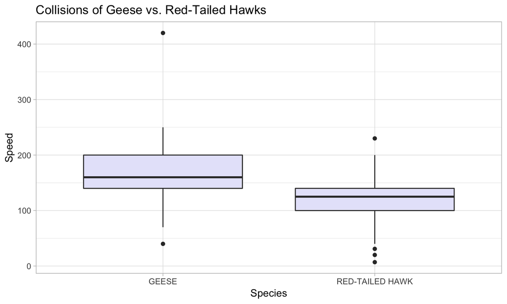

## Did the sky conditions affect the speeds at which they collided with the aircrafts?

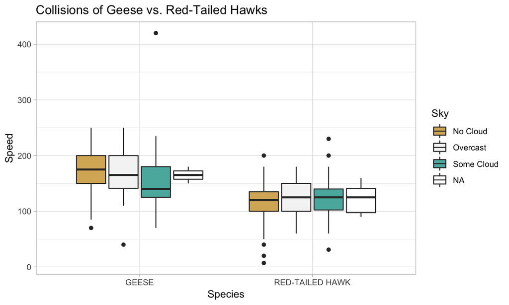